# Практика 20 · Перенавчання, недонавчання і розклад помилки

> 📖 **Теорія:** відкрий `lecture.html` у цій же теці. 📝 **Домашнє завдання:** `homework.html`. 🧠 **Тест:** `quiz.html`.

Лекція показала дві протилежні невдачі моделі й пояснила, звідки береться U-подібна крива. Тут ми відтворимо обидві хвороби своїми руками, а потім розкладемо помилку на три доданки й перевіримо, що вони справді сумуються.

**Що зробимо:**

> Числа тут не збігатимуться з лекцією до гривні: там дані породжував генератор браузера, тут — NumPy. Явище й усі висновки ті самі.

## 0. Світ, у якому ми знаємо істину

Уявімо дошку оголошень про вживані телефони рідкісної марки. Ціна залежить від року випуску: телефон дешевшає з віком, але не по прямій — свіжий флагман втрачає тисячі гривень за рік, а десятирічний апарат уже майже не дешевшає. Плюс невеликий горб на 2019-му: тодішня серія вийшла вдалою й тримає ціну краще за сусідні роки.

До цієї закономірності додається **шум** — усе, що не пояснюється роком: подряпина на корпусі, продавець поспішає, продавець поставив із запасом.

У житті істину ніхто не знає. Тут знаємо ми, бо самі її задали, — і саме тому зможемо показати пальцем, що модель вивчила закономірність, а що шум.

```python
import numpy as np
import matplotlib.pyplot as plt
from numpy.polynomial import legendre

FIRST_YEAR = 2010          # найстаріший телефон на дошці
LAST_YEAR = 2025           # найновіший
PRICE_NOISE = 750          # шум: стандартне відхилення в гривнях


def true_price(year):
    """Закономірність, якої модель не знає: здешевлення з віком плюс горб на 2019."""
    depreciation = 1900 + 18500 * 0.80 ** (LAST_YEAR - year)
    good_series = 1500 * np.exp(-((year - 2019) / 1.3) ** 2)
    return depreciation + good_series


def draw_board(rng, how_many):
    """Одна дошка оголошень: справжня ціна свого року плюс випадкове відхилення.

    Роки розкидаємо не як завгодно, а по одному з кожного рівного відрізка часу:
    саме так виглядає реальна дошка, де щороку зʼявляється кілька оголошень.
    Заодно це рятує підгонку — при випадкових роках два оголошення легко
    опиняються поруч, матриця ознак стає майже виродженою, і на високих степенях
    ми поміряли б похибку арифметики замість дисперсії моделі.
    """
    slots = np.arange(how_many)
    span = LAST_YEAR - FIRST_YEAR
    years = FIRST_YEAR + (slots + 0.14 + 0.72 * rng.random(how_many)) / how_many * span
    prices = true_price(years) + rng.normal(0, PRICE_NOISE, how_many)
    return years, prices


rng = np.random.default_rng(42)
train_years, train_prices = draw_board(rng, 16)
test_years, test_prices = draw_board(rng, 300)

print(f"навчальних оголошень: {len(train_years)}")
print(f"тестових оголошень:   {len(test_years)}")
print("\nперші пʼять навчальних оголошень:")
for year, price in zip(train_years[:5], train_prices[:5]):
    print(f"  {year:.2f} року — {price:8.0f} грн   "
          f"(типова ціна цього року: {true_price(year):.0f} грн)")
```

```
навчальних оголошень: 16
тестових оголошень:   300

перші пʼять навчальних оголошень:
  2010.65 року —     2930 грн   (типова ціна цього року: 2653 грн)
  2011.36 року —     2064 грн   (типова ціна цього року: 2783 грн)
  2012.59 року —     3718 грн   (типова ціна цього року: 3059 грн)
  2013.41 року —     3257 грн   (типова ціна цього року: 3294 грн)
  2013.94 року —     3331 грн   (типова ціна цього року: 3470 грн)
```

## 1. Модель: поліном, але обережно

Складність моделі регулює **степінь полінома**. Тут є технічна пастка, про яку варто знати заздалегідь.

Якщо будувати ознаки як сирі степені року — `[1, рік, рік², …, рік¹⁵]` — то при роках близько 2020 значення `рік¹⁵` має порядок 10⁴⁹. Стовпці матриці стають майже однаковими, система погано обумовлена, і на високих степенях ми отримаємо не перенавчання, а **чисельне сміття**.

Рятує це дві дії разом: спершу стиснути роки у відрізок `[-1, 1]`, потім узяти не сирі степені, а **поліноми Лежандра** — вони задають той самий простір функцій, але їхні стовпці майже ортогональні.

```python
def to_unit(years):
    """Стискаємо роки в [-1, 1]: без цього високі степені розвалюються чисельно."""
    return 2 * (years - FIRST_YEAR) / (LAST_YEAR - FIRST_YEAR) - 1


def fit_polynomial(years, prices, degree):
    """МНК-поліном заданого степеня. Повертає коефіцієнти в базисі Лежандра."""
    design = legendre.legvander(to_unit(years), degree)
    coefficients, *_ = np.linalg.lstsq(design, prices, rcond=None)
    return coefficients


def predict(coefficients, years):
    """Ціна, яку модель називає для кожного року."""
    degree = len(coefficients) - 1
    return legendre.legvander(to_unit(years), degree) @ coefficients


coefficients_3 = fit_polynomial(train_years, train_prices, 3)
print("коефіцієнти полінома 3-го степеня:", np.round(coefficients_3, 1))
print("прогноз для телефона 2020 року:",
      round(float(predict(coefficients_3, np.array([2020.0]))[0])), "грн")
```

```
коефіцієнти полінома 3-го степеня: [7586.6 7992.6 3556.1  666.1]
прогноз для телефона 2020 року: 8794 грн
```

Перевіримо, що всередині немає магії: та сама задача через `scikit-learn`, тільки на звичайних степенях. Простір функцій той самий — отже, прогноз має збігтися.

```python
from sklearn.pipeline import make_pipeline
from sklearn.preprocessing import PolynomialFeatures
from sklearn.linear_model import LinearRegression

library_model = make_pipeline(PolynomialFeatures(3), LinearRegression())
library_model.fit(to_unit(train_years).reshape(-1, 1), train_prices)

our_prediction = predict(coefficients_3, test_years)
library_prediction = library_model.predict(to_unit(test_years).reshape(-1, 1))

print(f"найбільше розходження: {np.abs(our_prediction - library_prediction).max():.2e} грн")

assert np.allclose(our_prediction, library_prediction), "розрахунок розійшовся!"
print("\n✅ збігається — усередині бібліотеки той самий МНК")
```

```
найбільше розходження: 1.18e-11 грн

✅ збігається — усередині бібліотеки той самий МНК
```

## 2. Помилка: одна формула, дві вибірки

Міряти будемо **RMSE** — корінь із середнього квадрата помилки. Зручність у тому, що результат виходить у гривнях: «модель у середньому промахується на стільки-то».

Головне тут не формула, а те, що ми рахуємо її **двічі**: на тих оголошеннях, за якими вчились, і на тих, яких модель не бачила.

```python
def rmse(actual, predicted):
    """Середня квадратична помилка в гривнях."""
    return float(np.sqrt(np.mean((actual - predicted) ** 2)))


def two_errors(degree, years, prices):
    """Помилка тієї самої моделі на навчальних і на тестових оголошеннях."""
    coefficients = fit_polynomial(years, prices, degree)
    on_train = rmse(prices, predict(coefficients, years))
    on_test = rmse(test_prices, predict(coefficients, test_years))
    return on_train, on_test


for degree in (1, 3, 9, 15):
    train_error, test_error = two_errors(degree, train_years, train_prices)
    print(f"степінь {degree:>2}:  навчання {train_error:9.0f} грн   тест {test_error:12.0f} грн")
```

```
степінь  1:  навчання      1638 грн   тест         1809 грн
степінь  3:  навчання       560 грн   тест          890 грн
степінь  9:  навчання       284 грн   тест         2385 грн
степінь 15:  навчання         0 грн   тест       401937 грн
```

Уже видно обидві хвороби. При степені 1 обидва числа високі й майже однакові — моделі бракує гнучкості. При степені 15 навчальна помилка практично нульова (коефіцієнтів рівно стільки ж, скільки оголошень, тож крива проходить точно через кожне), а тестова — астрономічна.

## 3. Уся таблиця степенів

Тепер порахуємо це для всіх степенів підряд і складемо в таблицю.

```python
import pandas as pd

rows = []
for degree in range(1, 16):
    train_error, test_error = two_errors(degree, train_years, train_prices)
    rows.append({"степінь": degree,
                 "помилка на навчанні": round(train_error),
                 "помилка на тесті": round(test_error),
                 "розрив": round(test_error - train_error)})

table = pd.DataFrame(rows).set_index("степінь")
print(table.to_string())
```

```
         помилка на навчанні  помилка на тесті  розрив
степінь
1                       1638              1809     171
2                        603               934     331
3                        560               890     331
4                        556               873     317
5                        555               866     311
6                        547               878     331
7                        399              1113     714
8                        392              1176     785
9                        284              2385    2101
10                       266              2341    2075
11                       266              2096    1830
12                       217              8270    8052
13                       176             18681   18505
14                        85             74842   74757
15                         0            401937  401937
```

## 4. Точка перелому

Читати таблицю очима незручно, тому знайдемо перелом програмно. Нас цікавлять дві речі:

- **найкращий степінь** — той, де тестова помилка найменша;
- **перший степінь, після якого тестова помилка пішла вгору, а навчальна далі падає.** Це і є момент переходу в перенавчання.

```python
train_errors = table["помилка на навчанні"].to_numpy()
test_errors = table["помилка на тесті"].to_numpy()
degrees_all = table.index.to_numpy()

best_degree = int(degrees_all[test_errors.argmin()])
best_error = int(test_errors.min())

print(f"найкращий степінь: {best_degree}")
print(f"його помилка на тесті: {best_error} грн")
print(f"його помилка на навчанні: {train_errors[test_errors.argmin()]} грн")
print()

# перевіряємо, що навчальна помилка справді ніколи не росте
always_falls = np.all(np.diff(train_errors) <= 0)
print(f"навчальна помилка ніколи не росте: {always_falls}")
print(f"а тестова після степеня {best_degree} — росте у "
      f"{int(np.sum(np.diff(test_errors[best_degree - 1:]) > 0))} випадках із "
      f"{len(test_errors) - best_degree}")
```

```
найкращий степінь: 5
його помилка на тесті: 866 грн
його помилка на навчанні: 555 грн

навчальна помилка ніколи не росте: True
а тестова після степеня 5 — росте у 8 випадках із 10
```

Тепер намалюємо те, заради чого все й затівалось: дві криві помилки. Шкала помилки логарифмічна — інакше степінь 15 розчавив би всю решту в лінію.

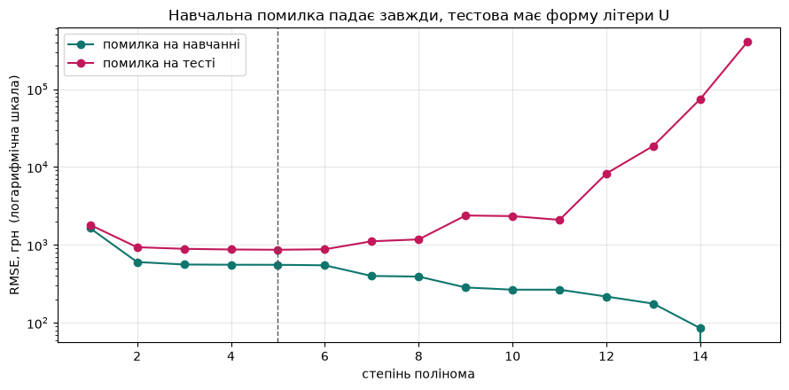

```
пунктир — найкращий степінь (5)
```

```python
fig, ax = plt.subplots(figsize=(9, 4.5))
ax.plot(degrees_all, train_errors, "o-", color="#0f766e", label="помилка на навчанні")
ax.plot(degrees_all, test_errors, "o-", color="#c2185b", label="помилка на тесті")
ax.axvline(best_degree, color="#555", linestyle="--", linewidth=1)
ax.set_yscale("log")
ax.set_xlabel("степінь полінома")
ax.set_ylabel("RMSE, грн  (логарифмічна шкала)")
ax.set_title("Навчальна помилка падає завжди, тестова має форму літери U")
ax.legend()
ax.grid(alpha=0.3)
plt.tight_layout()
plt.show()

print(f"пунктир — найкращий степінь ({best_degree})")
```

І три моделі поруч, щоб побачити ті самі числа очима: занадто проста, вдала й перенавчена.

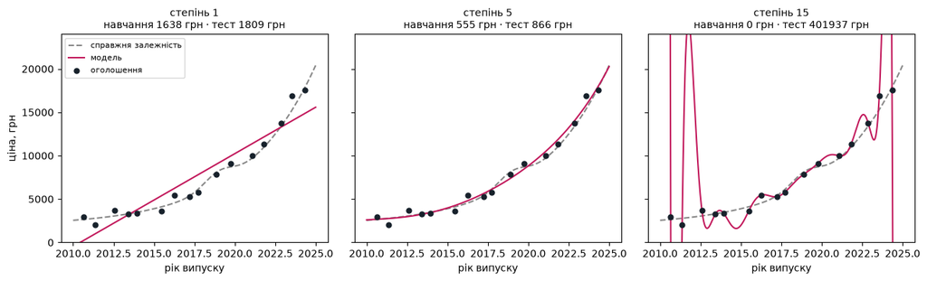

```
зверни увагу: права крива проходить точно через кожну точку — і саме тому вона найгірша
```

```python
year_grid = np.linspace(FIRST_YEAR, LAST_YEAR, 400)
fig, axes = plt.subplots(1, 3, figsize=(13, 4), sharey=True)

for ax, degree in zip(axes, (1, best_degree, 15)):
    coefficients = fit_polynomial(train_years, train_prices, degree)
    ax.plot(year_grid, true_price(year_grid), "--", color="#888", label="справжня залежність")
    ax.plot(year_grid, predict(coefficients, year_grid), color="#c2185b", label="модель")
    ax.scatter(train_years, train_prices, color="#17212b", zorder=3, s=25, label="оголошення")
    train_error, test_error = two_errors(degree, train_years, train_prices)
    ax.set_title(f"степінь {degree}\nнавчання {train_error:.0f} грн · тест {test_error:.0f} грн",
                 fontsize=10)
    ax.set_ylim(0, 24000)          # обрізаємо: поліном 15-го степеня вилітає на мільйони
    ax.set_xlabel("рік випуску")

axes[0].set_ylabel("ціна, грн")
axes[0].legend(fontsize=8)
plt.tight_layout()
plt.show()

print("зверни увагу: права крива проходить точно через кожну точку — і саме тому вона найгірша")
```

## 5. Та сама модель, але оголошень удесятеро більше

Складність моделі завжди відносна до обсягу даних. Поліном 9-го степеня на 16 оголошеннях — це складна модель. На 160 оголошеннях — цілком помірна.

Перевіримо: згенеруємо вдесятеро більшу дошку з того самого джерела й побудуємо ту саму таблицю.

```python
big_years, big_prices = draw_board(rng, 160)

big_rows = []
for degree in range(1, 16):
    train_error, test_error = two_errors(degree, big_years, big_prices)
    big_rows.append({"степінь": degree,
                     "помилка на навчанні": round(train_error),
                     "помилка на тесті": round(test_error),
                     "розрив": round(test_error - train_error)})

big_table = pd.DataFrame(big_rows).set_index("степінь")
print(big_table.to_string())
```

```
         помилка на навчанні  помилка на тесті  розрив
степінь
1                       1855              1795     -60
2                        903               911       7
3                        799               871      72
4                        743               830      88
5                        725               803      78
6                        715               804      89
7                        712               791      79
8                        709               790      81
9                        702               787      85
10                       702               785      83
11                       701               788      87
12                       691               792     101
13                       688               797     108
14                       679               796     117
15                       679               797     118
```

```python
best_on_16 = best_degree
best_on_160 = int(big_table["помилка на тесті"].idxmin())

print(f"на  16 оголошеннях найкращий степінь: {best_on_16}")
print(f"на 160 оголошеннях найкращий степінь: {best_on_160}")
print()

for degree in (9, 15):
    gap_16 = table.loc[degree, "розрив"]
    gap_160 = big_table.loc[degree, "розрив"]
    print(f"степінь {degree:>2}: розрив на 16 оголошеннях {gap_16:>9} грн, "
          f"на 160 — {gap_160:>6} грн")

print("\nмодель не змінилась ані на коефіцієнт — змінилось те, скільки їй довелось вигадувати")
```

```
на  16 оголошеннях найкращий степінь: 5
на 160 оголошеннях найкращий степінь: 10

степінь  9: розрив на 16 оголошеннях      2101 грн, на 160 —     85 грн
степінь 15: розрив на 16 оголошеннях    401937 грн, на 160 —    118 грн

модель не змінилась ані на коефіцієнт — змінилось те, скільки їй довелось вигадувати
```

## 6. Недонавчання в чистому вигляді

І контрольний дослід. Якщо перенавчання лікується даними, то, може, дані вилікують і недонавчання? Візьмемо пряму (степінь 1) і будемо давати їй усе більше й більше оголошень.

```python
sizes = [16, 40, 100, 400, 2000]
print(f"{'оголошень':>10} | {'навчання':>12} | {'тест':>12}")
print("-" * 40)
for size in sizes:
    some_years, some_prices = draw_board(rng, size)
    train_error, test_error = two_errors(1, some_years, some_prices)
    print(f"{size:>10} | {train_error:>9.0f} грн | {test_error:>9.0f} грн")

print("\nдві тисячі оголошень — і жодного покращення: пряма лишається прямою")
```

```
 оголошень |     навчання |         тест
----------------------------------------
        16 |      1577 грн |      1805 грн
        40 |      1780 грн |      1795 грн
       100 |      1901 грн |      1794 грн
       400 |      1828 грн |      1796 грн
      2000 |      1825 грн |      1795 грн

дві тисячі оголошень — і жодного покращення: пряма лишається прямою
```

Порівняй це з попереднім розділом. Там дані **різко** зменшили розрив між помилками. Тут вони не змінили нічого, бо проблема не в розриві: обидві помилки високі й однакові з самого початку.

Ось і вся діагностика в одному рядку: **дивись не на одну помилку, а на дві — і на відстань між ними.**

Досі ми дивились на симптоми. Тепер розберемо помилку на частини.

Головна ідея розділу 10 лекції: зміщення й дисперсія — властивості **процедури навчання**, а не однієї навченої моделі. Побачити їх на одному прогоні неможливо.

Тому влаштовуємо уявний експеримент по-справжньому: витягуємо багато різних дощок оголошень з того самого джерела, на кожній навчаємо свою модель і дивимось на розкид прогнозів.

```python
N_BOARDS = 200          # скільки паралельних дощок проживаємо
BOARD_SIZE = 16         # стільки ж оголошень, скільки в нашій єдиній дошці

# сітка років, на якій міряємо: краї відрізані, бо там будь-який поліном шаліє
# і числа перестають щось означати
grid_years = np.linspace(2011, 2024, 131)
grid_truth = true_price(grid_years)


def run_parallel_boards(degree, size=BOARD_SIZE, boards=N_BOARDS, seed=0):
    """Навчає `boards` моделей на різних дошках. Повертає матрицю прогнозів.

    Рядок — одна дошка, стовпець — один рік із сітки.
    """
    board_rng = np.random.default_rng(seed)
    predictions = np.zeros((boards, len(grid_years)))
    for board in range(boards):
        years, prices = draw_board(board_rng, size)
        predictions[board] = predict(fit_polynomial(years, prices, degree), grid_years)
    return predictions


predictions_degree_3 = run_parallel_boards(degree=3)
middle = len(grid_years) // 2
print(f"матриця прогнозів: {predictions_degree_3.shape} (дощок × років сітки)")
print(f"для {grid_years[middle]:.1f} року прогнози гуляють від "
      f"{predictions_degree_3[:, middle].min():.0f} до "
      f"{predictions_degree_3[:, middle].max():.0f} грн")
print(f"справжня ціна там: {grid_truth[middle]:.0f} грн")
```

```
матриця прогнозів: (200, 131) (дощок × років сітки)
для 2017.5 року прогнози гуляють від 4932 до 6545 грн
справжня ціна там: 5766 грн
```

### Віяло

Кожна тонка лінія — модель з окремої дошки. Товста рожева — **середня модель** $\bar{f}$, та сама, що стоїть у визначенні зміщення. Сірий пунктир — істина.

Дивись на дві речі **окремо**:

- наскільки товста лінія розходиться з пунктиром — це **зміщення**;
- наскільки широке віяло — це **дисперсія**.

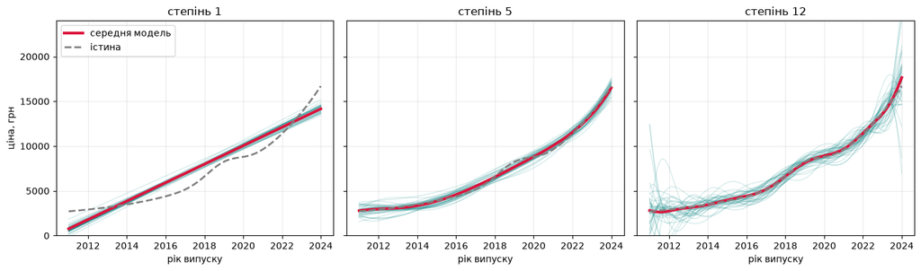

```
Степінь 1: усі прямі лежать майже одна на одній (дисперсії немає),
           але жодна навіть не намагається повторити горб 2019 року.
Степінь 12: середня крива лягла на істину чудово, зате окрема модель
           може дати будь-що. Це і є компроміс, буквально очима.
```

```python
fig, axes = plt.subplots(1, 3, figsize=(14, 4.2), sharey=True)

for ax, degree in zip(axes, [1, 5, 12]):
    predictions = run_parallel_boards(degree)
    # малюємо лише 40 дощок — інакше картинка перетвориться на суцільну пляму
    for board in range(40):
        ax.plot(grid_years, predictions[board], color="teal", alpha=.16, lw=1)
    ax.plot(grid_years, predictions.mean(axis=0), color="crimson", lw=3, label="середня модель")
    ax.plot(grid_years, grid_truth, color="grey", ls="--", lw=2, label="істина")
    ax.set_title(f"степінь {degree}")
    ax.set_xlabel("рік випуску")
    ax.grid(alpha=.25)

axes[0].set_ylabel("ціна, грн")
axes[0].set_ylim(0, 24000)
axes[0].legend(loc="upper left")
plt.tight_layout()
plt.show()

print("Степінь 1: усі прямі лежать майже одна на одній (дисперсії немає),")
print("           але жодна навіть не намагається повторити горб 2019 року.")
print("Степінь 12: середня крива лягла на істину чудово, зате окрема модель")
print("           може дати будь-що. Це і є компроміс, буквально очима.")
```

## 8. Рахуємо три доданки числом

Формули з лекції, слово в слово:

$$\text{Зміщення}(x) = \mathbb{E}_D[\hat{f}_D(x)] - f(x), \qquad \text{Дисперсія}(x) = \mathbb{E}_D\big[(\hat{f}_D(x) - \mathbb{E}_D[\hat{f}_D(x)])^2\big]$$

Сподівання $\mathbb{E}_D$ береться **по дошках** — тобто по рядках нашої матриці прогнозів. Потім усереднюємо по роках сітки, щоб отримати одне число на модель.

Величини виводимо в гривнях (корінь із доданка), щоб їх можна було порівняти з RMSE з першої половини зошита.

```python
def decompose(predictions):
    """Розкладає помилку на три доданки. Повертає (зміщення², дисперсія, шум)."""
    average_model = predictions.mean(axis=0)                  # f̄(x): середнє по дошках
    bias_squared = np.mean((average_model - grid_truth) ** 2)  # промах середньої моделі
    variance = np.mean(predictions.var(axis=0))                # розліт навколо середньої
    noise = PRICE_NOISE ** 2                                   # підлога, однакова завжди
    return bias_squared, variance, noise


print(f"{'степінь':>8} {'зміщення':>11} {'дисперсія':>11} {'шум':>8} {'разом':>9}")
for degree in [1, 3, 5, 8, 12]:
    bias_squared, variance, noise = decompose(run_parallel_boards(degree))
    print(f"{degree:>8} {np.sqrt(bias_squared):>11.0f} {np.sqrt(variance):>11.0f} "
          f"{np.sqrt(noise):>8.0f} {np.sqrt(bias_squared + variance + noise):>9.0f}")
print("\nусі числа — у гривнях; складаються вони в квадратах, тому «разом» —")
print("це корінь із суми квадратів, а не сума стовпців")
```

```
 степінь    зміщення   дисперсія      шум     разом
       1        1221         257      750      1456
       3         392         322      750       905
       5         253         414      750       893
       8         175         538      750       939
```

```
      12         143        1088      750      1329

усі числа — у гривнях; складаються вони в квадратах, тому «разом» —
це корінь із суми квадратів, а не сума стовпців
```

### Перевірка 1: доданки справді сумуються

Лекція наполягає, що розклад — **тотожність**, а не наближення. Перевіримо це буквально: порахуємо середній квадрат відхилення прогнозів від істини напряму, без жодного розкладу, і порівняємо зі сумою зміщення² та дисперсії.

```python
predictions = run_parallel_boards(degree=5)
bias_squared, variance, noise = decompose(predictions)

# «в лоб»: середній по дошках і по роках квадрат відхилення прогнозу від істини
straight_error = np.mean((predictions - grid_truth) ** 2)

print(f"зміщення² + дисперсія = {bias_squared + variance:.6f}")
print(f"пораховано напряму    = {straight_error:.6f}")

assert np.allclose(bias_squared + variance, straight_error), "розклад не сходиться!"
print("\n✅ тотожність підтверджена: доданків рівно два плюс шум, і вони не перекриваються")
```

```
зміщення² + дисперсія = 234905.800029
пораховано напряму    = 234905.800029

✅ тотожність підтверджена: доданків рівно два плюс шум, і вони не перекриваються
```

### Перевірка 2: а тепер із справжнім шумом

Попередня перевірка була алгебраїчною: істину ми знали точно. Тепер зробимо чесніше — у кожній дошці згенеруємо **нові зашумлені** ціни для років сітки, як у реальному житті, і поміряємо помилку на них.

Тут уже працює статистика, тому точного збігу не буде — лише збіг у межах похибки Монте-Карло. Саме так і має бути.

```python
noise_rng = np.random.default_rng(123)

# у кожній дошці — свій свіжий шум на роках сітки
noisy_prices = grid_truth + noise_rng.normal(0, PRICE_NOISE, predictions.shape)
measured_error = np.mean((noisy_prices - predictions) ** 2)

predicted_by_decomposition = bias_squared + variance + noise

print(f"поміряна помилка на зашумлених цінах: {np.sqrt(measured_error):.0f} грн")
print(f"передбачення розкладу:                {np.sqrt(predicted_by_decomposition):.0f} грн")
print(f"розбіжність: "
      f"{abs(measured_error - predicted_by_decomposition) / predicted_by_decomposition * 100:.2f}%")

assert np.allclose(measured_error, predicted_by_decomposition, rtol=0.05), \
    "розклад не описує реальну помилку!"
print("\n✅ розклад передбачає реальну помилку з точністю до похибки Монте-Карло")
```

```
поміряна помилка на зашумлених цінах: 895 грн
передбачення розкладу:                893 грн
розбіжність: 0.52%

✅ розклад передбачає реальну помилку з точністю до похибки Монте-Карло
```

## 9. Розклад по складності — головна картинка теми

Ті самі числа, але для всіх степенів одразу. Сірий фундамент однаковий скрізь: це шум, підлога, нижче якої не опуститься ніхто.

```python
degrees = np.arange(1, 13)
bias_by_degree = np.zeros(len(degrees))
variance_by_degree = np.zeros(len(degrees))

for i, degree in enumerate(degrees):
    bias_by_degree[i], variance_by_degree[i], _ = decompose(run_parallel_boards(degree))

total_by_degree = bias_by_degree + variance_by_degree + PRICE_NOISE ** 2
best_by_decomposition = degrees[total_by_degree.argmin()]

print(f"{'степінь':>8} {'зміщення':>11} {'дисперсія':>11} {'разом':>9}")
for i, degree in enumerate(degrees):
    mark = "  ← мінімум" if degree == best_by_decomposition else ""
    print(f"{degree:>8} {np.sqrt(bias_by_degree[i]):>11.0f} "
          f"{np.sqrt(variance_by_degree[i]):>11.0f} "
          f"{np.sqrt(total_by_degree[i]):>9.0f}{mark}")
```

```
 степінь    зміщення   дисперсія     разом
       1        1221         257      1456
       2         438         283       914
       3         392         322       905
       4         331         367       898
       5         253         414       893  ← мінімум
       6         249         457       913
       7         176         496       916
       8         175         538       939
       9         131         579       956
      10         108         654      1001
      11         115         802      1104
      12         143        1088      1329
```

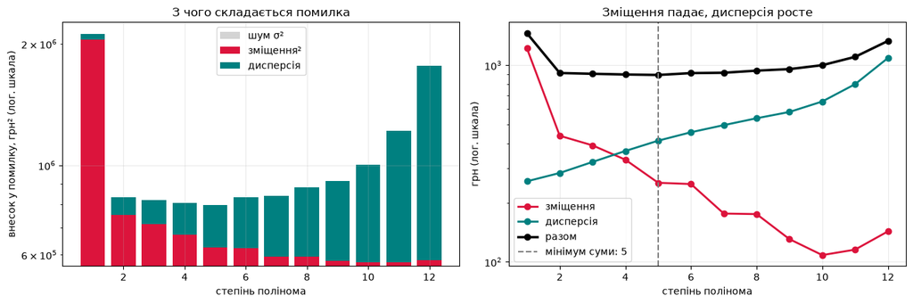

```
Мінімум суми — на степені 5. Зверни увагу: це не там, де
найменше зміщення, і не там, де найменша дисперсія. Оптимізувати треба суму.

На одній-єдиній дошці з розділу 4 переможцем теж вийшов степінь 5.
Пощастило: одна дошка не зобовʼязана давати ту саму відповідь, що й двісті.
Саме про це розділ 09 лекції: вибір за однією вибіркою систематично оптимістичний.
```

```python
fig, axes = plt.subplots(1, 2, figsize=(13, 4.4))

noise_row = np.full(len(degrees), PRICE_NOISE ** 2)
axes[0].bar(degrees, noise_row, color="lightgrey", label="шум σ²")
axes[0].bar(degrees, bias_by_degree, bottom=noise_row, color="crimson", label="зміщення²")
axes[0].bar(degrees, variance_by_degree, bottom=noise_row + bias_by_degree,
            color="teal", label="дисперсія")
axes[0].set_yscale("log")
axes[0].set_ylabel("внесок у помилку, грн² (лог. шкала)")
axes[0].set_title("З чого складається помилка")

axes[1].plot(degrees, np.sqrt(bias_by_degree), "o-", color="crimson", lw=2, label="зміщення")
axes[1].plot(degrees, np.sqrt(variance_by_degree), "o-", color="teal", lw=2, label="дисперсія")
axes[1].plot(degrees, np.sqrt(total_by_degree), "o-", color="black", lw=2.5, label="разом")
axes[1].axvline(best_by_decomposition, ls="--", color="grey",
                label=f"мінімум суми: {best_by_decomposition}")
axes[1].set_yscale("log")
axes[1].set_ylabel("грн (лог. шкала)")
axes[1].set_title("Зміщення падає, дисперсія росте")

for ax in axes:
    ax.set_xlabel("степінь полінома")
    ax.legend()
    ax.grid(alpha=.25)
plt.tight_layout()
plt.show()

print(f"Мінімум суми — на степені {best_by_decomposition}. Зверни увагу: це не там, де")
print("найменше зміщення, і не там, де найменша дисперсія. Оптимізувати треба суму.")
print()
if best_by_decomposition == best_degree:
    print(f"На одній-єдиній дошці з розділу 4 переможцем теж вийшов степінь {best_degree}.")
    print("Пощастило: одна дошка не зобовʼязана давати ту саму відповідь, що й двісті.")
else:
    print(f"А на одній-єдиній дошці з розділу 4 переможцем був степінь {best_degree}.")
    print("Розбіжність не помилка: там ми міряли одну дошку, тут — середнє по двохстах.")
print("Саме про це розділ 09 лекції: вибір за однією вибіркою систематично оптимістичний.")
```

## 10. Бутстреп: те саме, коли дошка одна

Паралельні дошки — уявний експеримент. Але дещо схоже можна зробити й насправді: **бутстреп**. Беремо одну наявну дошку й багато разів витягуємо з неї $n$ оголошень **з поверненням**. Кожна така підвибірка трохи інша — от і «паралельні дошки», зроблені з підручних матеріалів.

Бутстреп не знає істини, тому зміщення він оцінити не може. А от **дисперсію** — цілком: вона не потребує знання $f$.

```python
def bootstrap_predictions(years, prices, degree, resamples=N_BOARDS, seed=5):
    """Багато моделей, навчених на підвибірках з поверненням з однієї дошки."""
    boot_rng = np.random.default_rng(seed)
    size = len(years)
    predictions = np.zeros((resamples, len(grid_years)))
    for i in range(resamples):
        # витягуємо номери рядків з поверненням — частина оголошень повториться,
        # частина не потрапить зовсім, і саме це створює різницю між моделями
        chosen = boot_rng.integers(0, size, size)
        predictions[i] = predict(
            fit_polynomial(years[chosen], prices[chosen], degree), grid_years)
    return predictions


print(f"{'степінь':>8} {'дисперсія (200 дощок)':>23} {'дисперсія (бутстреп)':>23} {'відношення':>12}")
for degree in [1, 3, 5]:
    _, ideal_variance, _ = decompose(run_parallel_boards(degree))
    bootstrap_variance = np.mean(
        bootstrap_predictions(train_years, train_prices, degree).var(axis=0))
    print(f"{degree:>8} {np.sqrt(ideal_variance):>20.0f} грн "
          f"{np.sqrt(bootstrap_variance):>20.0f} грн "
          f"{np.sqrt(bootstrap_variance / ideal_variance):>12.2f}")

print("\nНапрямок бутстреп ловить правильно: зі складністю дисперсія росте.")
print("А от абсолютні числа він завищує, і тим сильніше, чим складніша модель.")
print("Причина: підвибірка з поверненням містить у середньому лише 63% різних")
print("оголошень. Гнучкому поліному цього критично мало — він хапається за дублікати,")
print("і його розкид роздувається. Тому бутстреп — індикатор, а не вимірювальний прилад.")
```

```
 степінь   дисперсія (200 дощок)    дисперсія (бутстреп)   відношення
       1                  257 грн                  675 грн         2.63
       3                  322 грн                  429 грн         1.33
```

[output not shown]

## 11. Дані бʼють лише по дисперсії

Лекція: $\text{Дисперсія} \approx C/n$, а зміщення від $n$ **не залежить взагалі**. Перевіримо обидва твердження одразу, зафіксувавши складність.

```python
board_sizes = np.array([20, 40, 80, 160, 320])
bias_by_size = np.zeros(len(board_sizes))
variance_by_size = np.zeros(len(board_sizes))

for i, size in enumerate(board_sizes):
    predictions = run_parallel_boards(degree=5, size=int(size), boards=120)
    bias_by_size[i], variance_by_size[i], _ = decompose(predictions)

print(f"{'n':>6} {'зміщення':>11} {'дисперсія':>11} {'дисперсія × n':>16}")
for i, size in enumerate(board_sizes):
    print(f"{size:>6} {np.sqrt(bias_by_size[i]):>11.0f} {np.sqrt(variance_by_size[i]):>11.0f} "
          f"{variance_by_size[i] * size:>16.0f}")

print("\nЗміщення стоїть на місці — скільки даних не давай, поліном 5-го степеня")
print("лишиться поліномом 5-го степеня. Це і є сенс слова «систематична».")
print(f"\nА дисперсія × n майже не рухається: {variance_by_size[0] * board_sizes[0]:.0f} → "
      f"{variance_by_size[-1] * board_sizes[-1]:.0f}, тоді як сама n виросла в "
      f"{board_sizes[-1] // board_sizes[0]} разів.")
print("Тобто дисперсія падає приблизно як 1/n.")
```

```
     n    зміщення   дисперсія    дисперсія × n
    20         257         349          2434083
    40         258         265          2803071
    80         258         190          2875519
   160         258         128          2640119
   320         256          90          2612620

Зміщення стоїть на місці — скільки даних не давай, поліном 5-го степеня
лишиться поліномом 5-го степеня. Це і є сенс слова «систематична».

А дисперсія × n майже не рухається: 2434083 → 2612620, тоді як сама n виросла в 16 разів.
Тобто дисперсія падає приблизно як 1/n.
```

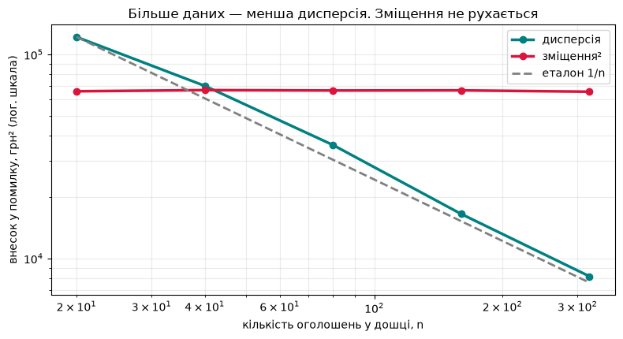

```
Бірюзова крива йде вниз паралельно сірому еталону — це і є закон 1/n.
Рожева лежить майже горизонтально: дані на зміщення не діють.
```

```python
fig, ax = plt.subplots(figsize=(8, 4.4))

ax.loglog(board_sizes, variance_by_size, "o-", color="teal", lw=2.5, label="дисперсія")
ax.loglog(board_sizes, bias_by_size, "o-", color="crimson", lw=2.5, label="зміщення²")
# еталонний нахил 1/n, привʼязаний до першої точки
reference = variance_by_size[0] * board_sizes[0] / board_sizes
ax.loglog(board_sizes, reference, ls="--", color="grey", lw=2, label="еталон 1/n")

ax.set_xlabel("кількість оголошень у дошці, n")
ax.set_ylabel("внесок у помилку, грн² (лог. шкала)")
ax.set_title("Більше даних — менша дисперсія. Зміщення не рухається")
ax.legend()
ax.grid(alpha=.25, which="both")
plt.tight_layout()
plt.show()

print("Бірюзова крива йде вниз паралельно сірому еталону — це і є закон 1/n.")
print("Рожева лежить майже горизонтально: дані на зміщення не діють.")
```

## 12. Ті самі криві готовими інструментами

Усе, що ми рахували руками, у `scikit-learn` уже є двома функціями. Писати руками було потрібно, щоб зрозуміти, **що саме** вони рахують, — тепер можна користуватися.

- `validation_curve` — помилка від **складності** (наша U-подібна крива);
- `learning_curve` — помилка від **розміру вибірки** (та сама крива навчання, яку лекція радить будувати перед тим, як замовляти нові дані).

Обидві всередині роблять крос-валідацію, тому дають чесніші числа, ніж одне відкладене розбиття. Візьмемо дошку на 150 оголошень, щоб кривій навчання було куди рости.

```python
from sklearn.model_selection import validation_curve, learning_curve, KFold
from sklearn.preprocessing import StandardScaler

curve_rng = np.random.default_rng(11)
curve_years, curve_prices = draw_board(curve_rng, 150)
curve_x = to_unit(curve_years).reshape(-1, 1)      # sklearn чекає матрицю, а не вектор

# у конвеєрі степінь стоїть окремим кроком — саме його ми й будемо крутити
polynomial_model = make_pipeline(PolynomialFeatures(), StandardScaler(), LinearRegression())
folds = KFold(n_splits=5, shuffle=True, random_state=0)

degree_range = np.arange(1, 19)
train_scores, test_scores = validation_curve(
    polynomial_model, curve_x, curve_prices,
    param_name="polynomialfeatures__degree", param_range=degree_range,
    cv=folds, scoring="neg_root_mean_squared_error")

# sklearn повертає «чим більше, тим краще», тому міняємо знак назад
train_rmse = -train_scores.mean(axis=1)
test_rmse = -test_scores.mean(axis=1)
best_by_library = degree_range[test_rmse.argmin()]

print(f"{'степінь':>8} {'train':>10} {'test (CV)':>12}")
for i, degree in enumerate(degree_range):
    mark = "  ← мінімум" if degree == best_by_library else ""
    print(f"{degree:>8} {train_rmse[i]:>7.0f} грн {test_rmse[i]:>9.0f} грн{mark}")

print(f"\nvalidation_curve на дошці зі 150 оголошень каже: степінь {best_by_library}.")
print(f"Наш чесний експеримент із {N_BOARDS} паралельними дошками по 16 оголошень")
print(f"казав: степінь {best_by_decomposition}. Більша дошка дозволяє складнішу модель —")
print("рівно те, що ми бачили в розділі 5.")
```

```
 степінь      train    test (CV)
       1    1758 грн      1810 грн
       2     761 грн       773 грн
       3     735 грн       761 грн
       4     701 грн       778 грн
       5     676 грн       730 грн
       6     674 грн       727 грн
       7     661 грн       734 грн
       8     646 грн       704 грн
       9     642 грн       699 грн
      10     633 грн       698 грн  ← мінімум
      11     631 грн       700 грн
      12     625 грн       725 грн
      13     623 грн       726 грн
      14     617 грн       740 грн
      15     614 грн       730 грн
      16     612 грн       739 грн
      17     609 грн       742 грн
      18     607 грн       878 грн

validation_curve на дошці зі 150 оголошень каже: степінь 10.
Наш чесний експеримент із 200 паралельними дошками по 16 оголошень
казав: степінь 5. Більша дошка дозволяє складнішу модель —
рівно те, що ми бачили в розділі 5.
```

[figure not shown]

```
Читаємо праву картинку так, як радить лекція:
  степінь 1 — крива вийшла на плато високо над підлогою. Дані вже не
              допоможуть, проблема в моделі. Замовляти розмітку — марно.
  степінь 5 — крива тисне до підлоги 750 грн. Ось тут нові дані
              справді куплять тобі якість.
```

```python
fig, axes = plt.subplots(1, 2, figsize=(13, 4.4))

axes[0].plot(degree_range, train_rmse, "o-", color="crimson", lw=2.5, label="train")
axes[0].plot(degree_range, test_rmse, "o-", color="teal", lw=2.5, label="test (CV)")
axes[0].axvline(best_by_library, ls="--", color="grey", label=f"мінімум: {best_by_library}")
axes[0].set_xlabel("степінь полінома")
axes[0].set_title("validation_curve: помилка від складності")

# крива навчання для замалої і для доречної моделі
for degree, colour in [(1, "crimson"), (5, "teal")]:
    train_sizes, _, holdout_scores = learning_curve(
        make_pipeline(PolynomialFeatures(degree), StandardScaler(), LinearRegression()),
        curve_x, curve_prices, train_sizes=np.linspace(0.2, 1.0, 7),
        cv=folds, scoring="neg_root_mean_squared_error")
    axes[1].plot(train_sizes, -holdout_scores.mean(axis=1), "o-", color=colour, lw=2.5,
                 label=f"степінь {degree}")

axes[1].axhline(PRICE_NOISE, ls=":", color="grey", label="підлога 750 грн")
axes[1].set_xlabel("кількість навчальних оголошень")
axes[1].set_title("learning_curve: помилка від кількості даних")

for ax in axes:
    ax.set_ylabel("RMSE, грн")
    ax.legend()
    ax.grid(alpha=.25)
plt.tight_layout()
plt.show()

print("Читаємо праву картинку так, як радить лекція:")
print("  степінь 1 — крива вийшла на плато високо над підлогою. Дані вже не")
print("              допоможуть, проблема в моделі. Замовляти розмітку — марно.")
print("  степінь 5 — крива тисне до підлоги 750 грн. Ось тут нові дані")
print("              справді куплять тобі якість.")
```

## 13. Уся діагностика в одній таблиці

```python
print("що бачу                                    | діагноз       | що робити")
print("-" * 92)
print("обидві високі, розриву майже немає         | недонавчання  | ускладнити модель, додати ознак")
print("обидві низькі, розрив невеликий            | усе гаразд    | не чіпати")
print("навчальна дуже низька, тестова помітно вища| перенавчання  | спростити, додати даних, регуляризація")
print()
print("а якщо треба знати, ЧОМУ саме так:")
print("  вузьке віяло, середня крива мимо істини  | зміщення      | ускладнити")
print("  широке віяло, середня крива по істині    | дисперсія     | спростити або добути дані")
```

```
що бачу                                    | діагноз       | що робити
--------------------------------------------------------------------------------------------
обидві високі, розриву майже немає         | недонавчання  | ускладнити модель, додати ознак
обидві низькі, розрив невеликий            | усе гаразд    | не чіпати
навчальна дуже низька, тестова помітно вища| перенавчання  | спростити, додати даних, регуляризація

а якщо треба знати, ЧОМУ саме так:
  вузьке віяло, середня крива мимо істини  | зміщення      | ускладнити
  широке віяло, середня крива по істині    | дисперсія     | спростити або добути дані
```

## 💻 Завдання

### 🟢 Рівень 1 — База

1. Заміни `PRICE_NOISE` із 750 на 200 і перебудуй таблицю з розділу 3. Назви новий найкращий степінь і поясни одним реченням, чому при меншому шумі вигідно брати складнішу модель.
2. Перебудуй розділ 9 із тим самим меншим шумом. Який доданок змінився, а які лишились на місці? Куди зсунувся мінімум суми?

**Зроблено, якщо:** обидва найкращі степені названі й ти пояснив(ла), чому вони зсунулись в один бік.

### 🟡 Рівень 2 — Плюс

1. Заміни поліном на **k-NN** (`sklearn.neighbors.KNeighborsRegressor`) і побудуй ту саму таблицю зміщення/дисперсії, але по $k$ від 1 до 15. Функція `run_parallel_boards` майже не зміниться — треба лише інакше навчати модель.
2. Окремо перевір крайні випадки: $k = 1$ і $k = n$ (усі оголошення в сусідах).

**Зроблено, якщо:** видно **дзеркальну** картину до полінома — при $k=1$ дисперсія максимальна, а зміщення мінімальне; при $k = n$ модель вироджується в константу (нульова дисперсія, величезне зміщення). І ти написав(ла) одним реченням, що саме усереднює k-NN, коли $k$ росте.

### 🔴 Рівень 3 — Виклик

Вибір степеня по тестовій вибірці — це підглядання у відповідь (розділ 09 лекції). Поміряй, скільки коштує це підглядання.

1. Розбий дошку на три частини: навчальну, валідаційну й тестову.
2. Обери найкращий степінь **за валідаційною** частиною.
3. Поміряй помилку обраної моделі на валідаційній і на тестовій частинах.
4. Повтори кроки 1–3 щонайменше 30 разів із різними розбиттями й усередни обидва числа.

**Зроблено, якщо:** ти отримав(ла) дві середні величини — помилку на валідації та на тесті — показав(ла), що перша систематично менша, назвав(ла) цю різницю числом і пояснив(ла), звідки вона береться.

### Підказки

- Для рівня 1 достатньо перезапустити зошит згори з іншою константою; але памʼятай, що `rng` треба створити наново, інакше числа поїдуть.
- Для рівня 2 у k-NN «складність» крутиться в **протилежний** бік: маленьке $k$ — складна модель. Тому й таблиця вийде дзеркальною.
- Для рівня 3 не пиши цикл із нуля: `sklearn.model_selection.train_test_split` з різним `random_state` розбиває дані заново кожного разу.